# 1_Project_WalkThrough

John Kearns

2023-11-29

Context for this analysis: Look at what variables were impacting the likelihood of an immigrant to be naturalized, as per a vote by their community members.

Load packages:

```r
library(tidyverse)
library(estimatr)
library(texreg)
library(robustbase)
library(vtable)
library(sandwich)
library(lmtest)
```

Load data:

```r
#
setwd("C:/Users/16094/Documents/Year 2 - Princeton/Fall 2023/R Tutoring/SPIA_R_Seminars/Week 6/")

#
data = haven::read_dta("Data/swiss_passports.dta")
```

1. Construct a table of summary statistics for the variables in the data set. Is there anything noteworthy from the overall statistics? Any obvious differences if you look at europeans versus people from Turkey?

```r
st(data)
```

Summary Statistics

| Variable | N | Mean | Std. Dev. | Min | Pctl. 25 | Pctl. 75 | Max |
| --- | --- | --- | --- | --- | --- | --- | --- |
| land_neu_poor | 1397 | 0.021 | 0.15 | 0 | 0 | 0 | 1 |
| land_asia | 1397 | 0.073 | 0.26 | 0 | 0 | 0 | 1 |
| year80 | 1397 | 0.16 | 0.37 | 0 | 0 | 0 | 1 |
| year90 | 1397 | 0.36 | 0.48 | 0 | 0 | 1 | 1 |
| year00 | 1397 | 0.39 | 0.49 | 0 | 0 | 1 | 1 |
| age40 | 1397 | 0.48 | 0.5 | 0 | 0 | 1 | 1 |
| age60 | 1397 | 0.34 | 0.47 | 0 | 0 | 1 | 1 |
| age60plus | 1397 | 0.029 | 0.17 | 0 | 0 | 0 | 1 |
| male | 1397 | 0.72 | 0.45 | 0 | 0 | 1 | 1 |
| kids | 1397 | 0.52 | 0.5 | 0 | 0 | 1 | 1 |
| educ_middle | 1397 | 0.58 | 0.49 | 0 | 0 | 1 | 1 |
| educ_high | 1397 | 0.11 | 0.32 | 0 | 0 | 0 | 1 |
| married | 1397 | 0.56 | 0.5 | 0 | 0 | 1 | 1 |
| lang_perfect | 1397 | -0.27 | 0.93 | -1 | -1 | 1 | 1 |
| lang_good | 1397 | -0.56 | 0.58 | -1 | -1 | 0 | 1 |
| lang_insufficient | 1397 | -0.6 | 0.49 | -1 | -1 | 0 | 1 |
| lang_NA | 1397 | 0.61 | 0.49 | 0 | 0 | 1 | 1 |
| integration_NA | 1397 | 0.39 | 0.49 | 0 | 0 | 1 | 1 |
| integration_integrated | 1397 | -0.18 | 0.79 | -1 | -1 | 0 | 2 |
| integration_assimilated | 1397 | -0.1 | 0.9 | -1 | -1 | 0 | 2 |
| integration_adjusted | 1397 | -0.38 | 0.51 | -1 | -1 | 0 | 1 |
| integration_nodifference | 1397 | -0.34 | 0.58 | -1 | -1 | 0 | 1 |
| land_ty | 1397 | 0.5 | 0.5 | 0 | 0 | 1 | 1 |
| land_ceeu | 1397 | 0.064 | 0.24 | 0 | 0 | 0 | 1 |
| land_seu | 1397 | 0.17 | 0.37 | 0 | 0 | 0 | 1 |
| land_other | 1397 | 0.18 | 0.38 | 0 | 0 | 0 | 1 |
| skill_hi | 1397 | 0.42 | 0.49 | 0 | 0 | 1 | 1 |
| skill_middle | 1397 | 0.17 | 0.37 | 0 | 0 | 0 | 1 |
| born_ch | 1397 | 0.21 | 0.41 | 0 | 0 | 0 | 1 |
| percent_novotes | 1397 | 40 | 15 | 4 | 29 | 52 | 88 |

```r
st(data %>% filter(land_seu==1))
```

Summary Statistics

| Variable | N | Mean | Std. Dev. | Min | Pctl. 25 | Pctl. 75 | Max |
| --- | --- | --- | --- | --- | --- | --- | --- |
| land_neu_poor | 232 | 0 | 0 | 0 | 0 | 0 | 0 |
| land_asia | 232 | 0 | 0 | 0 | 0 | 0 | 0 |
| year80 | 232 | 0.21 | 0.41 | 0 | 0 | 0 | 1 |
| year90 | 232 | 0.34 | 0.47 | 0 | 0 | 1 | 1 |
| year00 | 232 | 0.3 | 0.46 | 0 | 0 | 1 | 1 |
| age40 | 232 | 0.55 | 0.5 | 0 | 0 | 1 | 1 |
| age60 | 232 | 0.27 | 0.44 | 0 | 0 | 1 | 1 |
| age60plus | 232 | 0.017 | 0.13 | 0 | 0 | 0 | 1 |
| male | 232 | 0.65 | 0.48 | 0 | 0 | 1 | 1 |
| kids | 232 | 0.4 | 0.49 | 0 | 0 | 1 | 1 |
| educ_middle | 232 | 0.66 | 0.48 | 0 | 0 | 1 | 1 |
| educ_high | 232 | 0.052 | 0.22 | 0 | 0 | 0 | 1 |
| married | 232 | 0.46 | 0.5 | 0 | 0 | 1 | 1 |
| lang_perfect | 232 | -0.18 | 0.98 | -1 | -1 | 1 | 1 |
| lang_good | 232 | -0.57 | 0.52 | -1 | -1 | 0 | 1 |
| lang_insufficient | 232 | -0.58 | 0.49 | -1 | -1 | 0 | 0 |
| lang_NA | 232 | 0.58 | 0.49 | 0 | 0 | 1 | 1 |
| integration_NA | 232 | 0.42 | 0.49 | 0 | 0 | 1 | 1 |
| integration_integrated | 232 | -0.21 | 0.84 | -1 | -1 | 0 | 2 |
| integration_assimilated | 232 | -0.13 | 0.94 | -1 | -1 | 0 | 2 |
| integration_adjusted | 232 | -0.42 | 0.49 | -1 | -1 | 0 | 0 |
| integration_nodifference | 232 | -0.33 | 0.63 | -1 | -1 | 0 | 1 |
| land_ty | 232 | 0 | 0 | 0 | 0 | 0 | 0 |
| land_ceeu | 232 | 0 | 0 | 0 | 0 | 0 | 0 |
| land_seu | 232 | 1 | 0 | 1 | 1 | 1 | 1 |
| land_other | 232 | 0 | 0 | 0 | 0 | 0 | 0 |
| skill_hi | 232 | 0.54 | 0.5 | 0 | 0 | 1 | 1 |
| skill_middle | 232 | 0.11 | 0.32 | 0 | 0 | 0 | 1 |
| born_ch | 232 | 0.6 | 0.49 | 0 | 0 | 1 | 1 |
| percent_novotes | 232 | 29 | 12 | 4 | 23 | 35 | 76 |

```r
st(data %>% filter(land_ty==1))
```

Summary Statistics

| Variable | N | Mean | Std. Dev. | Min | Pctl. 25 | Pctl. 75 | Max |
| --- | --- | --- | --- | --- | --- | --- | --- |
| land_neu_poor | 695 | 0 | 0 | 0 | 0 | 0 | 0 |
| land_asia | 695 | 0 | 0 | 0 | 0 | 0 | 0 |
| year80 | 695 | 0.055 | 0.23 | 0 | 0 | 0 | 1 |
| year90 | 695 | 0.38 | 0.48 | 0 | 0 | 1 | 1 |
| year00 | 695 | 0.57 | 0.5 | 0 | 0 | 1 | 1 |
| age40 | 695 | 0.51 | 0.5 | 0 | 0 | 1 | 1 |
| age60 | 695 | 0.29 | 0.45 | 0 | 0 | 1 | 1 |
| age60plus | 695 | 0.016 | 0.12 | 0 | 0 | 0 | 1 |
| male | 695 | 0.71 | 0.46 | 0 | 0 | 1 | 1 |
| kids | 695 | 0.53 | 0.5 | 0 | 0 | 1 | 1 |
| educ_middle | 695 | 0.54 | 0.5 | 0 | 0 | 1 | 1 |
| educ_high | 695 | 0.071 | 0.26 | 0 | 0 | 0 | 1 |
| married | 695 | 0.57 | 0.5 | 0 | 0 | 1 | 1 |
| lang_perfect | 695 | -0.13 | 0.95 | -1 | -1 | 1 | 1 |
| lang_good | 695 | -0.47 | 0.61 | -1 | -1 | 0 | 1 |
| lang_insufficient | 695 | -0.53 | 0.51 | -1 | -1 | 0 | 1 |
| lang_NA | 695 | 0.53 | 0.5 | 0 | 0 | 1 | 1 |
| integration_NA | 695 | 0.38 | 0.49 | 0 | 0 | 1 | 1 |
| integration_integrated | 695 | -0.12 | 0.83 | -1 | -1 | 0 | 2 |
| integration_assimilated | 695 | -0.2 | 0.77 | -1 | -1 | 0 | 2 |
| integration_adjusted | 695 | -0.37 | 0.51 | -1 | -1 | 0 | 1 |
| integration_nodifference | 695 | -0.33 | 0.57 | -1 | -1 | 0 | 1 |
| land_ty | 695 | 1 | 0 | 1 | 1 | 1 | 1 |
| land_ceeu | 695 | 0 | 0 | 0 | 0 | 0 | 0 |
| land_seu | 695 | 0 | 0 | 0 | 0 | 0 | 0 |
| land_other | 695 | 0 | 0 | 0 | 0 | 0 | 0 |
| skill_hi | 695 | 0.38 | 0.49 | 0 | 0 | 1 | 1 |
| skill_middle | 695 | 0.11 | 0.32 | 0 | 0 | 0 | 1 |
| born_ch | 695 | 0.15 | 0.36 | 0 | 0 | 0 | 1 |
| percent_novotes | 695 | 48 | 13 | 8 | 42 | 57 | 88 |

```r
# what might we want to do to have a pretty table?
```

1.a. percent_novotes is the outcome variable of interest. What is its average value? What is its standard deviation? Applications are approved if the fraction of no votes is less than 50 percent. What fraction of citizenship applications were approved?

```r
summary(data$percent_novotes)
```

```
##    Min. 1st Qu.  Median    Mean 3rd Qu.    Max.
##    4.00   29.00   42.00   40.35   52.00   88.00
```

```r
data = data %>%
  mutate(percent_approved = ifelse(percent_novotes<50,1,0))

sd(data$percent_novotes)
```

```
## [1] 14.78252
```

```r
summary(data$percent_approved)
```

```
##    Min. 1st Qu.  Median    Mean 3rd Qu.    Max.
##   0.000   0.000   1.000   0.685   1.000   1.000
```

1.b. The various land_ variables are the explanatory variables of interest. What fraction of applications were from Turkey and Yugoslavia? From Central and Eastern Europe? etc. How did this fraction vary over the 1970-2003 sample period? Make a plot of this

```r
mean(data$land_ty==1|data$land_ceeu==1)
```

```
## [1] 0.5612026
```

```r
data = data %>%
  mutate(nationality=case_when(
    land_ty==1~"Turkey",
    land_ceeu==1~"Yugoslavia",
    land_asia==1~"Asia",
    land_seu==1~"Southern Europe",
    land_neu_poor==1~"NonEuropean Poor",
    land_other==1~"Other"
  ),
  decade=case_when(
    year80==1~"1980",
    year90==1~"1990",
    year00==1~"2000",
    year80==0&year90==0&year00==0~"1970"
  ))

data %>%
        group_by(nationality) %>%
        summarize(Share=n()/nrow(data))
```

```
## # A tibble: 6 × 2
##   nationality       Share
##   <chr>             <dbl>
## 1 Asia             0.0730
## 2 NonEuropean Poor 0.0215
## 3 Other            0.178
## 4 Southern Europe  0.166
## 5 Turkey           0.497
## 6 Yugoslavia       0.0637
```

```r
data %>%
        group_by(decade,nationality) %>%
        summarize(Share=n()/nrow(data[data$decade==decade,])) %>%
        ungroup() %>%
        pivot_wider(names_from=nationality,values_from=Share)
```

```
## # A tibble: 4 × 7
##   decade   Asia `NonEuropean Poor`  Other `Southern Europe`  Turkey Yugoslavia
##   <chr>   <dbl>              <dbl>  <dbl>             <dbl>   <dbl>      <dbl>
## 1 1970   0.0155            0.00775 0.628              0.279 0.00775     0.0620
## 2 1980   0.0176            0.0132  0.463              0.211 0.167       0.128
## 3 1990   0.141             0.0298  0.0795             0.155 0.519       0.0755
## 4 2000   0.0465            0.0204  0.0428             0.130 0.734       0.0260
```

2. 1. Construct table showing land_ and columns are number of obs, mean of percent_novotes, sd, standard error, and 95% confidence interval for the mean

```r
data %>%
        group_by(nationality) %>%
        summarize(num_obs = n(),
                  mean = mean(percent_novotes),
                  st_dev = sd(percent_novotes),
                  st_error = plotrix::std.error(percent_novotes),
                  ci95_low = mean-1.96*st_error,
                  ci95_high = mean+1.96*st_error)
```

```
## # A tibble: 6 × 7
##   nationality      num_obs  mean st_dev st_error ci95_low ci95_high
##   <chr>              <int> <dbl>  <dbl>    <dbl>    <dbl>     <dbl>
## 1 Asia                 102  39.1   10.3    1.02      37.1      41.1
## 2 NonEuropean Poor      30  37.1   13.6    2.48      32.3      42.0
## 3 Other                249  30.2   10.9    0.688     28.8      31.5
## 4 Southern Europe      232  28.9   11.8    0.776     27.4      30.4
## 5 Turkey               695  48.3   12.6    0.480     47.3      49.2
## 6 Yugoslavia            89  39.4   13.6    1.45      36.6      42.3
```

3.a. Show the impact of nationality in regression form on percent of no votes received

```r
mod1 = lm_robust(percent_novotes~land_ty+land_asia+land_ceeu+land_seu+land_neu_poor,data=data,se_type="stata")
# land_other is excluded so that there is no perfect collinearity

# from this we see how the significance of these differences from the mean varies by source country.
# Turkey has the largest magnitude, while Asia and Yugoslavia are around the same, relative to the "other" countries.
# Southern Europe get the best outcomes in votes, though the difference be SEU and "other" is not statistically significant.

summary(mod1)
```

```
##
## Call:
## lm_robust(formula = percent_novotes ~ land_ty + land_asia + land_ceeu +
##     land_seu + land_neu_poor, data = data, se_type = "stata")
##
## Standard error type:  HC1
##
## Coefficients:
##               Estimate Std. Error t value   Pr(>|t|) CI Lower CI Upper   DF
## (Intercept)     30.169     0.6879  43.855 1.598e-264   28.819  31.5181 1391
## land_ty         18.086     0.8390  21.558  3.638e-89   16.440  19.7318 1391
## land_asia        8.969     1.2297   7.293  5.055e-13    6.556  11.3808 1391
## land_ceeu        9.258     1.5960   5.801  8.155e-09    6.127  12.3891 1391
## land_seu        -1.268     1.0370  -1.223  2.217e-01   -3.302   0.7665 1391
## land_neu_poor    6.965     2.5383   2.744  6.150e-03    1.985  11.9439 1391
##
## Multiple R-squared:  0.3284 ,    Adjusted R-squared:  0.326
## F-statistic: 140.8 on 5 and 1391 DF,  p-value: < 2.2e-16
```

3. Add skill level to regression

```r
data = data %>%
  mutate(integration_integrated=ifelse(integration_integrated==-1,NA,integration_integrated),
         integration_assimilated=ifelse(integration_assimilated==-1,NA,integration_assimilated))

mod2 = lm_robust(percent_novotes~land_ty+land_asia+land_ceeu+land_seu+land_neu_poor+skill_hi+skill_middle,data=data,se_type="stata")

summary(mod2)
```

```
##
## Call:
## lm_robust(formula = percent_novotes ~ land_ty + land_asia + land_ceeu +
##     land_seu + land_neu_poor + skill_hi + skill_middle, data = data,
##     se_type = "stata")
##
## Standard error type:  HC1
##
## Coefficients:
##               Estimate Std. Error t value   Pr(>|t|) CI Lower CI Upper   DF
## (Intercept)     32.234     0.9034  35.682 1.855e-198   30.462  34.0058 1389
## land_ty         17.201     0.8971  19.174  6.992e-73   15.441  18.9607 1389
## land_asia        8.108     1.2564   6.453  1.511e-10    5.643  10.5724 1389
## land_ceeu        8.896     1.6076   5.534  3.747e-08    5.742  12.0492 1389
## land_seu        -1.824     1.0632  -1.715  8.649e-02   -3.909   0.2618 1389
## land_neu_poor    6.704     2.4920   2.690  7.225e-03    1.816  11.5927 1389
## skill_hi        -2.105     0.7246  -2.904  3.739e-03   -3.526  -0.6831 1389
## skill_middle    -3.347     1.0039  -3.334  8.779e-04   -5.317  -1.3779 1389
##
## Multiple R-squared:  0.3354 ,    Adjusted R-squared:  0.3321
## F-statistic:   106 on 7 and 1389 DF,  p-value: < 2.2e-16
```

3.c. male, kids, married, born_ch, age, and education all may be helpful

```r
mod3 = lm_robust(percent_novotes~land_ty+land_asia+land_ceeu+land_seu+land_neu_poor+year80+year90+year00+male+kids+married+born_ch+age60+age60plus+educ_high+skill_hi,data=data,se_type="stata")

summary(mod3)
```

```
##
## Call:
## lm_robust(formula = percent_novotes ~ land_ty + land_asia + land_ceeu +
##     land_seu + land_neu_poor + year80 + year90 + year00 + male +
##     kids + married + born_ch + age60 + age60plus + educ_high +
##     skill_hi, data = data, se_type = "stata")
##
## Standard error type:  HC1
##
## Coefficients:
##               Estimate Std. Error  t value  Pr(>|t|) CI Lower CI Upper   DF
## (Intercept)   28.08649     1.4420 19.47801 7.588e-75 25.25782  30.9152 1380
## land_ty       16.33408     1.1800 13.84278 6.652e-41 14.01935  18.6488 1380
## land_asia      6.83350     1.4434  4.73422 2.425e-06  4.00195   9.6651 1380
## land_ceeu      8.21849     1.6322  5.03525 5.402e-07  5.01665  11.4203 1380
## land_seu      -1.46094     1.2332 -1.18470 2.363e-01 -3.88002   0.9581 1380
## land_neu_poor  5.43620     2.7341  1.98830 4.698e-02  0.07277  10.7996 1380
## year80         0.07498     1.3142  0.05706 9.545e-01 -2.50298   2.6529 1380
## year90         3.46423     1.3898  2.49270 1.279e-02  0.73798   6.1905 1380
## year00         2.04565     1.4519  1.40900 1.591e-01 -0.80242   4.8937 1380
## male           1.36553     0.8306  1.64405 1.004e-01 -0.26383   2.9949 1380
## kids           0.77784     1.2027  0.64674 5.179e-01 -1.58149   3.1372 1380
## married        0.85134     1.1876  0.71684 4.736e-01 -1.47841   3.1811 1380
## born_ch       -1.40307     0.9301 -1.50848 1.317e-01 -3.22768   0.4215 1380
## age60         -0.22649     0.8294 -0.27307 7.848e-01 -1.85355   1.4006 1380
## age60plus     -0.12391     1.5732 -0.07876 9.372e-01 -3.21013   2.9623 1380
## educ_high     -1.98679     1.0832 -1.83420 6.684e-02 -4.11167   0.1381 1380
## skill_hi      -0.18509     0.7431 -0.24908 8.033e-01 -1.64280   1.2726 1380
##
## Multiple R-squared:  0.3423 ,    Adjusted R-squared:  0.3347
## F-statistic: 48.26 on 16 and 1380 DF,  p-value: < 2.2e-16
```

3.d. 1. How many non-NA observations on the language and integration variable?

```r
sum(data$lang_NA==0)
```

```
## [1] 551
```

```r
# 551 out of 1397

sum(data$integration_NA==0)
```

```
## [1] 851
```

3.d. 2. Do the conclusions I reach in part c change if I restrict the samples based on availability of language data?

```r
mod4 = lm_robust(percent_novotes~land_ty+land_asia+land_ceeu+land_seu+land_neu_poor+year80+year90+year00+male+kids+married+born_ch+age60+age60plus+educ_high+skill_hi,data=data %>% filter(lang_NA==0),se_type="stata")

mod5 = lm_robust(percent_novotes~land_ty+land_asia+land_ceeu+land_seu+land_neu_poor+year80+year90+year00+male+kids+married+born_ch+age60+age60plus+educ_high+skill_hi,data=data %>% filter(integration_NA==0),se_type="stata")

summary(mod4)
```

```
##
## Call:
## lm_robust(formula = percent_novotes ~ land_ty + land_asia + land_ceeu +
##     land_seu + land_neu_poor + year80 + year90 + year00 + male +
##     kids + married + born_ch + age60 + age60plus + educ_high +
##     skill_hi, data = data %>% filter(lang_NA == 0), se_type = "stata")
##
## Standard error type:  HC1
##
## Coefficients:
##               Estimate Std. Error  t value  Pr(>|t|) CI Lower CI Upper  DF
## (Intercept)   27.45377      2.129 12.89794 2.516e-33   23.272  31.6351 534
## land_ty       15.39028      2.060  7.47213 3.246e-13   11.344  19.4364 534
## land_asia      6.83965      2.398  2.85278 4.502e-03    2.130  11.5494 534
## land_ceeu      2.88746      3.033  0.95200 3.415e-01   -3.071   8.8456 534
## land_seu      -2.49620      2.024 -1.23317 2.181e-01   -6.473   1.4802 534
## land_neu_poor  4.06837      4.366  0.93190 3.518e-01   -4.508  12.6444 534
## year80         0.83405      2.167  0.38494 7.004e-01   -3.422   5.0903 534
## year90         8.84449      2.053  4.30858 1.956e-05    4.812  12.8770 534
## year00        10.00967      2.145  4.66656 3.877e-06    5.796  14.2233 534
## male          -0.06454      1.019 -0.06336 9.495e-01   -2.065   1.9363 534
## kids          -1.83614      1.814 -1.01246 3.118e-01   -5.399   1.7264 534
## married        1.70543      1.667  1.02313 3.067e-01   -1.569   4.9799 534
## born_ch       -2.69213      1.177 -2.28702 2.259e-02   -5.005  -0.3797 534
## age60         -1.13350      1.172 -0.96733 3.338e-01   -3.435   1.1684 534
## age60plus     -2.93614      2.751 -1.06730 2.863e-01   -8.340   2.4679 534
## educ_high      1.41142      1.680  0.84003 4.013e-01   -1.889   4.7120 534
## skill_hi      -0.23639      1.084 -0.21806 8.275e-01   -2.366   1.8931 534
##
## Multiple R-squared:  0.487 , Adjusted R-squared:  0.4717
## F-statistic: 37.47 on 16 and 534 DF,  p-value: < 2.2e-16
```

```r
# the magnitudes are lower for those where language is available, but especially for those from Yugoslavia

summary(mod5)
```

```
##
## Call:
## lm_robust(formula = percent_novotes ~ land_ty + land_asia + land_ceeu +
##     land_seu + land_neu_poor + year80 + year90 + year00 + male +
##     kids + married + born_ch + age60 + age60plus + educ_high +
##     skill_hi, data = data %>% filter(integration_NA == 0), se_type = "stata")
##
## Standard error type:  HC1
##
## Coefficients:
##               Estimate Std. Error t value  Pr(>|t|) CI Lower CI Upper  DF
## (Intercept)   28.33369     1.4251 19.8814 2.689e-72  25.5364  31.1310 834
## land_ty       16.07431     1.2909 12.4523 9.106e-33  13.5406  18.6080 834
## land_asia      6.80977     1.5573  4.3728 1.382e-05   3.7531   9.8665 834
## land_ceeu      7.87940     1.8601  4.2360 2.529e-05   4.2284  11.5304 834
## land_seu      -0.73781     1.3414 -0.5500 5.825e-01  -3.3708   1.8951 834
## land_neu_poor 10.66587     1.8327  5.8198 8.398e-09   7.0687  14.2631 834
## year80         1.28708     1.3531  0.9512 3.418e-01  -1.3688   3.9430 834
## year90         5.80397     1.3702  4.2359 2.530e-05   3.1145   8.4934 834
## year00         5.84409     1.4448  4.0449 5.720e-05   3.0082   8.6799 834
## male           1.27753     0.8180  1.5617 1.187e-01  -0.3281   2.8832 834
## kids          -1.11586     1.1600 -0.9620 3.363e-01  -3.3927   1.1610 834
## married        1.91662     1.1469  1.6712 9.506e-02  -0.3345   4.1677 834
## born_ch       -2.67022     0.9166 -2.9132 3.673e-03  -4.4693  -0.8711 834
## age60         -0.30580     0.8376 -0.3651 7.152e-01  -1.9499   1.3383 834
## age60plus     -1.58199     1.7776 -0.8899 3.738e-01  -5.0711   1.9072 834
## educ_high     -0.84604     1.1017 -0.7679 4.428e-01  -3.0085   1.3165 834
## skill_hi       0.02408     0.7546  0.0319 9.746e-01  -1.4571   1.5053 834
##
## Multiple R-squared:  0.4872 ,    Adjusted R-squared:  0.4774
## F-statistic: 51.74 on 16 and 834 DF,  p-value: < 2.2e-16
```

```r
# in this subset, the neu_poor coefficient doubles in size, but the rest are essentially unchanged
```

3.d.3. add language variables as additional controls

```r
data = data %>%
  mutate_at(vars(lang_perfect:lang_insufficient),funs(ifelse(.==-1,NA,.)))
mod6 = lm_robust(percent_novotes~land_ty+land_asia+land_ceeu+land_seu+land_neu_poor+year80+year90+year00+male+kids+married+born_ch+age60+age60plus+educ_high+skill_hi+lang_good+lang_perfect,data=data %>% filter(integration_NA==0),se_type="stata")
summary(mod6)
```

```
##
## Call:
## lm_robust(formula = percent_novotes ~ land_ty + land_asia + land_ceeu +
##     land_seu + land_neu_poor + year80 + year90 + year00 + male +
##     kids + married + born_ch + age60 + age60plus + educ_high +
##     skill_hi + lang_good + lang_perfect, data = data %>% filter(integration_NA ==
##     0), se_type = "stata")
##
## Standard error type:  HC1
##
## Coefficients:
##               Estimate Std. Error t value  Pr(>|t|) CI Lower CI Upper  DF
## (Intercept)    34.0215      3.133 10.8607 1.622e-24   27.865  40.1781 442
## land_ty        16.4886      2.044  8.0680 6.799e-15   12.472  20.5052 442
## land_asia       6.1449      2.445  2.5132 1.232e-02    1.340  10.9502 442
## land_ceeu       2.7255      3.047  0.8944 3.716e-01   -3.263   8.7142 442
## land_seu       -1.4490      1.979 -0.7321 4.645e-01   -5.339   2.4409 442
## land_neu_poor  12.5806      2.796  4.4993 8.726e-06    7.085  18.0759 442
## year80          1.6200      2.038  0.7951 4.270e-01   -2.384   5.6244 442
## year90          8.9009      1.995  4.4621 1.031e-05    4.980  12.8213 442
## year00          8.4784      2.087  4.0625 5.744e-05    4.377  12.5800 442
## male            0.4468      1.052  0.4248 6.712e-01   -1.620   2.5139 442
## kids           -3.2080      1.729 -1.8553 6.422e-02   -6.606   0.1903 442
## married         2.1600      1.638  1.3189 1.879e-01   -1.059   5.3787 442
## born_ch        -2.9139      1.179 -2.4722 1.380e-02   -5.230  -0.5974 442
## age60          -1.3807      1.137 -1.2147 2.251e-01   -3.615   0.8532 442
## age60plus      -5.4934      2.020 -2.7195 6.796e-03   -9.463  -1.5233 442
## educ_high       1.6953      1.727  0.9815 3.269e-01   -1.699   5.0898 442
## skill_hi       -0.1330      1.095 -0.1215 9.033e-01   -2.284   2.0183 442
## lang_good      -5.2381      2.252 -2.3264 2.045e-02   -9.663  -0.8129 442
## lang_perfect   -6.6504      2.169 -3.0657 2.305e-03  -10.914  -2.3870 442
##
## Multiple R-squared:  0.5453 ,    Adjusted R-squared:  0.5268
## F-statistic: 36.38 on 18 and 442 DF,  p-value: < 2.2e-16
```

3.d.4. Add the integration variables

```r
data = data %>%
  mutate_at(vars(integration_integrated:integration_nodifference),funs(ifelse(.==-1,NA,.)))
mod7 = lm_robust(percent_novotes~land_ty+land_asia+
                   land_ceeu+land_seu+land_neu_poor+year80+
                   year90+year00+male+kids+married+born_ch+
                   age60+age60plus+educ_high+skill_hi+
                   lang_good+lang_perfect+factor(integration_integrated)+
                   factor(integration_assimilated)+integration_adjusted+
                   integration_nodifference,data=data %>% filter(integration_NA==0),se_type="stata")
summary(mod7)
```

```
##
## Call:
## lm_robust(formula = percent_novotes ~ land_ty + land_asia + land_ceeu +
##     land_seu + land_neu_poor + year80 + year90 + year00 + male +
##     kids + married + born_ch + age60 + age60plus + educ_high +
##     skill_hi + lang_good + lang_perfect + factor(integration_integrated) +
##     factor(integration_assimilated) + integration_adjusted +
##
## Standard error type:  HC1
##
## Coefficients:
##                                    Estimate Std. Error t value  Pr(>|t|)
## (Intercept)                         33.7152     3.0446 11.0738 2.813e-25
## land_ty                             17.3411     1.9568  8.8621 2.028e-17
## land_asia                            6.6341     2.5374  2.6145 9.245e-03
## land_ceeu                            5.7281     2.5693  2.2295 2.629e-02
## land_seu                            -1.4611     1.9100 -0.7650 4.447e-01
## land_neu_poor                       13.5970     2.4777  5.4878 6.924e-08
## year80                               0.8469     2.1237  0.3988 6.902e-01
## year90                               9.8630     2.1292  4.6322 4.785e-06
## year00                               9.4053     2.2002  4.2748 2.353e-05
## male                                 1.1318     1.0001  1.1316 2.584e-01
## kids                                -2.0884     1.3217 -1.5801 1.148e-01
## married                              1.5869     1.3569  1.1695 2.428e-01
## born_ch                             -3.5065     1.0674 -3.2850 1.102e-03
## age60                               -1.3539     0.9976 -1.3572 1.754e-01
## age60plus                           -4.6952     2.3806 -1.9723 4.921e-02
## educ_high                            2.0588     1.3544  1.5201 1.292e-01
## skill_hi                             0.1668     1.0047  0.1660 8.682e-01
## lang_good                           -3.9988     2.2045 -1.8139 7.038e-02
## lang_perfect                        -5.2630     2.1420 -2.4571 1.440e-02
## factor(integration_integrated)1     -5.1211     1.0493 -4.8807 1.487e-06
## factor(integration_integrated)2     -1.2908     1.6630 -0.7762 4.381e-01
## factor(integration_assimilated)1    -2.8079     1.6637 -1.6878 9.217e-02
## factor(integration_assimilated)1.5 -24.1165     2.4635 -9.7894 1.390e-20
## factor(integration_assimilated)2     0.5460     1.7126  0.3188 7.500e-01
## integration_adjusted                -4.8069     2.0649 -2.3279 2.037e-02
## integration_nodifference            -3.4525     1.3442 -2.5685 1.055e-02
##                                    CI Lower  CI Upper  DF
## (Intercept)                         27.7312  39.69909 435
```

[output cut: 13 more lines]

```
## age60plus                           -9.3741  -0.01638 435
## educ_high                           -0.6032   4.72077 435
## skill_hi                            -1.8079   2.14150 435
## lang_good                           -8.3317   0.33409 435
## lang_perfect                        -9.4729  -1.05307 435
## factor(integration_integrated)1     -7.1833  -3.05882 435
## factor(integration_integrated)2     -4.5594   1.97777 435
## factor(integration_assimilated)1    -6.0777   0.46191 435
## factor(integration_assimilated)1.5 -28.9585 -19.27462 435
## factor(integration_assimilated)2    -2.8200   3.91189 435
## integration_adjusted                -8.8653  -0.74855 435
## integration_nodifference            -6.0944  -0.81060 435
##
## Multiple R-squared:  0.6528 ,    Adjusted R-squared:  0.6329
## F-statistic:    44 on 25 and 435 DF,  p-value: < 2.2e-16
```

4. Do the land_ coefficients depend on occupation skills or educational level

```r
mod8 = lm_robust(percent_novotes~land_ty+land_asia+
                   land_ceeu+land_seu+land_neu_poor+
                   educ_high+educ_middle+skill_middle+skill_hi,data=data %>% filter(integration_NA==0),se_type="stata")

summary(mod8)
```

```
##
## Call:
## lm_robust(formula = percent_novotes ~ land_ty + land_asia + land_ceeu +
##     land_seu + land_neu_poor + educ_high + educ_middle + skill_middle +
##     skill_hi, data = data %>% filter(integration_NA == 0), se_type = "stata")
##
## Standard error type:  HC1
##
## Coefficients:
##               Estimate Std. Error t value   Pr(>|t|) CI Lower CI Upper  DF
## (Intercept)    32.1633     1.1204 28.7063 7.215e-127   29.964 34.36250 841
## land_ty        19.2622     0.9866 19.5243  2.662e-70   17.326 21.19865 841
## land_asia      10.1351     1.3881  7.3013  6.610e-13    7.410 12.85966 841
## land_ceeu      10.3641     1.8610  5.5691  3.445e-08    6.711 14.01678 841
## land_seu       -0.5063     1.1599 -0.4365  6.626e-01   -2.783  1.77034 841
## land_neu_poor  13.5213     2.1665  6.2410  6.886e-10    9.269 17.77370 841
## educ_high       1.2054     1.3147  0.9169  3.595e-01   -1.375  3.78590 841
## educ_middle     0.1368     0.7487  0.1827  8.551e-01   -1.333  1.60625 841
## skill_middle   -3.0876     1.1897 -2.5953  9.614e-03   -5.423 -0.75253 841
## skill_hi       -1.4916     0.7469 -1.9972  4.613e-02   -2.958 -0.02567 841
##
## Multiple R-squared:  0.4663 ,    Adjusted R-squared:  0.4606
## F-statistic: 90.23 on 9 and 841 DF,  p-value: < 2.2e-16
```

```r
# it does appear that these variables are important

mod9 = lm_robust(percent_novotes~land_ty*educ_high+land_ty*educ_middle+land_ty*skill_middle+land_ty*skill_hi+
                   land_asia*educ_high+land_asia*educ_middle+land_asia*skill_middle+land_asia*skill_hi+
                   land_ceeu*educ_high+land_ceeu*educ_middle+land_ceeu*skill_middle+land_ceeu*skill_hi+
                   land_seu*educ_high+land_seu*educ_middle+land_seu*skill_middle+land_seu*skill_hi+
                   land_neu_poor*educ_high+land_neu_poor*educ_middle+land_neu_poor*skill_middle+land_neu_poor*skill_hi+
                   educ_high+educ_middle+skill_middle+skill_hi,data=data %>% filter(integration_NA==0),se_type="stata")

summary(mod9)
```

```
##
## Call:
## lm_robust(formula = percent_novotes ~ land_ty * educ_high + land_ty *
##     educ_middle + land_ty * skill_middle + land_ty * skill_hi +
##     land_asia * educ_high + land_asia * educ_middle + land_asia *
##     skill_middle + land_asia * skill_hi + land_ceeu * educ_high +
##     land_ceeu * educ_middle + land_ceeu * skill_middle + land_ceeu *
##
## Standard error type:  HC1
##
## Coefficients:
##                            Estimate Std. Error t value  Pr(>|t|) CI Lower
## (Intercept)                  23.839      2.049 11.6330 4.624e-29  19.8163
## land_ty                      28.913      2.165 13.3542 5.932e-37  24.6634
## educ_high                     9.674      2.590  3.7344 2.012e-04   4.5891
## educ_middle                   4.939      1.959  2.5213 1.188e-02   1.0940
## skill_middle                  1.233      2.255  0.5470 5.845e-01  -3.1920
## skill_hi                      3.407      1.985  1.7163 8.648e-02  -0.4894
## land_asia                    19.624      2.634  7.4490 2.383e-13  14.4532
## land_ceeu                    18.166      5.078  3.5770 3.678e-04   8.1976
## land_seu                      6.460      2.961  2.1818 2.941e-02   0.6483
## land_neu_poor                23.828      4.254  5.6013 2.903e-08  15.4780
## land_ty:educ_high           -13.333      3.345 -3.9866 7.300e-05 -19.8980
## land_ty:educ_middle          -5.590      2.176 -2.5686 1.039e-02  -9.8611
## land_ty:skill_middle         -5.804      3.020 -1.9218 5.498e-02 -11.7320
## land_ty:skill_hi             -5.844      2.210 -2.6450 8.324e-03 -10.1815
## educ_high:land_asia          -4.581      4.694 -0.9760 3.294e-01 -13.7948
## educ_middle:land_asia        -6.434      2.938 -2.1896 2.883e-02 -12.2017
## skill_middle:land_asia       -8.926      5.278 -1.6914 9.115e-02 -19.2855
## skill_hi:land_asia           -6.103      2.941 -2.0751 3.829e-02 -11.8760
## educ_high:land_ceeu          -8.714      6.393 -1.3631 1.732e-01 -21.2620
## educ_middle:land_ceeu        -6.110      5.548 -1.1012 2.711e-01 -17.0004
## skill_middle:land_ceeu       -2.705      5.069 -0.5337 5.937e-01 -12.6561
## skill_hi:land_ceeu           -2.694      5.202 -0.5179 6.047e-01 -12.9050
## educ_high:land_seu           -7.705      3.879 -1.9862 4.734e-02 -15.3196
## educ_middle:land_seu         -2.286      2.776 -0.8236 4.104e-01  -7.7355
## skill_middle:land_seu        -3.946      3.725 -1.0592 2.898e-01 -11.2573
## skill_hi:land_seu            -5.451      2.782 -1.9595 5.039e-02 -10.9119
## educ_high:land_neu_poor     -16.340      4.721 -3.4609 5.662e-04 -25.6080
## educ_middle:land_neu_poor     3.394      4.211  0.8060 4.205e-01  -4.8717
```

[output cut: 21 more lines]

```
## educ_high:land_ceeu         3.834071 821
## educ_middle:land_ceeu       4.780450 821
## skill_middle:land_ceeu      7.245170 821
## skill_hi:land_ceeu          7.517132 821
## educ_high:land_seu         -0.090538 821
## educ_middle:land_seu        3.162607 821
## skill_middle:land_seu       3.365951 821
## skill_hi:land_seu           0.009368 821
## educ_high:land_neu_poor    -7.072926 821
## educ_middle:land_neu_poor  11.660422 821
## skill_middle:land_neu_poor  6.441940 821
## skill_hi:land_neu_poor     -8.751725 821
##
## Multiple R-squared:  0.4922 ,    Adjusted R-squared:  0.4743
## F-statistic:    NA on 29 and 821 DF,  p-value: NA
```

```r
# there are significant interaction effects for Asians and those with middle education or high skilled occupations
# Same for SEU and high education
# High education and NEU
# Turkey for all the education and skill variables
# the education and skill variables has less interaction effects for Yugoslavia and SEU
# the education and skill variables get positive coefficients now, so all effect is subsumed in the interaction terms
```

Plot the nationality coefficients by decade to see any possible changes

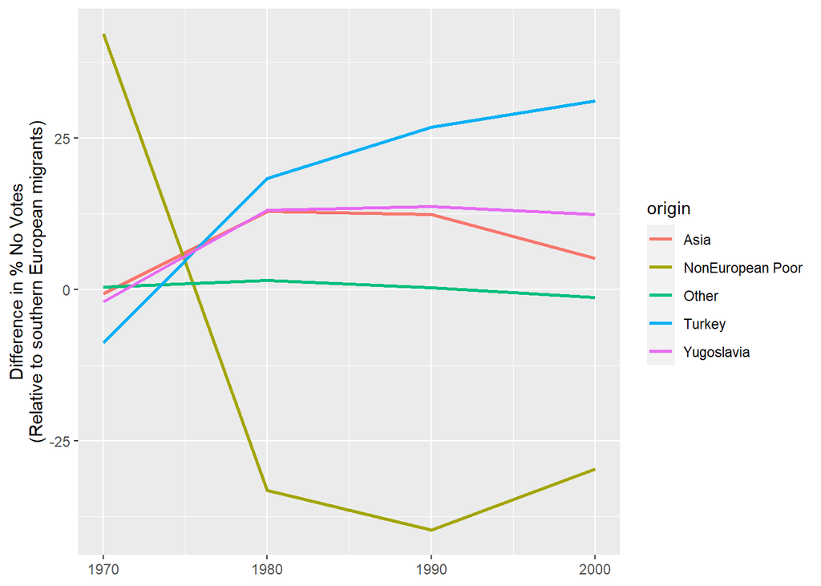

```r
mod10 = lm_robust(percent_novotes~land_ty*decade+
                    land_ceeu*decade+
                    #land_seu*decade+
                    land_asia*decade+
                    land_neu_poor*decade+
                    land_other*decade,data=data,se_type="stata")


time_fe_results = tidy(mod10)
time_fe_fig_data = data.frame()
for(country in c("ty","ceeu","other","asia","poor")){

  decades=c(1970,1980,1990,2000)
  coeffs = time_fe_results$estimate[grep(country,time_fe_results$term)]

  time_fe_fig_data = bind_rows(time_fe_fig_data,
                               data.frame(decade=decades,
                                          coef=coeffs,
                                          origin=country))

}

time_fe_fig_data = time_fe_fig_data %>%
  mutate(origin=case_when(
    origin=="ty"~"Turkey",
    origin=="ceeu"~"Yugoslavia",
    origin=="other"~"Other",
    origin=="asia"~"Asia",
    origin=="poor"~"NonEuropean Poor"
  )) %>%
  rowwise() %>%
  mutate(num_migrants=100*nrow(data[data$nationality==origin&data$decade==decade,])/nrow(data[data$decade==decade,])) %>%
  ungroup()

ggplot(time_fe_fig_data,aes(x=decade,y=coef,color=origin)) +
  geom_line(size=1) +
  labs(x="Decade",y="Difference in % No Votes\n(Relative to southern European migrants)") +
  theme(axis.title = element_text(), axis.title.x = element_blank())
```